# Forest Fires in Portugal

1. This information includes data regarding forest fires in the Northeast region of Portugal. The data uses meteorological and other data with the hopes of finding trends to better prepare for forest fires in this region. This information was taken from the UCI repository https://archive.ics.uci.edu/ml/datasets/forest+fires.

2.Simply looking at the summary statistics and the data file suggests skewed information regarding the FFMC numbers since the median is much closer to the max value than the minimal. The minimum value of 18.7 appears to be an outlier and graphing the data confirms that the data is skewed left.

3.Through the machine learning, we are trying to predict Homoscedacity to see if the variance of the dependent variable is the same for all of the data.

4.We have plotted this data to better understand the results and split parts of the data amongst itself.

```r
library(tidyverse)
library(caret)
```

```r
summary(forestfires)
```

```
       X               Y          month               day                 FFMC
 Min.   :1.000   Min.   :2.0   Length:517         Length:517         Min.   :18.70
 1st Qu.:3.000   1st Qu.:4.0   Class :character   Class :character   1st Qu.:90.20
 Median :4.000   Median :4.0   Mode  :character   Mode  :character   Median :91.60
 Mean   :4.669   Mean   :4.3                                         Mean   :90.64
 3rd Qu.:7.000   3rd Qu.:5.0                                         3rd Qu.:92.90
 Max.   :9.000   Max.   :9.0                                         Max.   :96.20
      DMC              DC             ISI              temp             RH
 Min.   :  1.1   Min.   :  7.9   Min.   : 0.000   Min.   : 2.20   Min.   : 15.00
 1st Qu.: 68.6   1st Qu.:437.7   1st Qu.: 6.500   1st Qu.:15.50   1st Qu.: 33.00
 Median :108.3   Median :664.2   Median : 8.400   Median :19.30   Median : 42.00
 Mean   :110.9   Mean   :547.9   Mean   : 9.022   Mean   :18.89   Mean   : 44.29
 3rd Qu.:142.4   3rd Qu.:713.9   3rd Qu.:10.800   3rd Qu.:22.80   3rd Qu.: 53.00
 Max.   :291.3   Max.   :860.6   Max.   :56.100   Max.   :33.30   Max.   :100.00
      wind            rain              area
 Min.   :0.400   Min.   :0.00000   Min.   :   0.00
 1st Qu.:2.700   1st Qu.:0.00000   1st Qu.:   0.00
 Median :4.000   Median :0.00000   Median :   0.52
 Mean   :4.018   Mean   :0.02166   Mean   :  12.85
 3rd Qu.:4.900   3rd Qu.:0.00000   3rd Qu.:   6.57
 Max.   :9.400   Max.   :6.40000   Max.   :1090.84
```

Running this code below simply verifies that there are in fact 517 observations and 13 variables which match up to the data documentation for the dataset (12 predictors plus an area outcome).

```r
# Number of data cases and variables
dim(forestfires)
```

```
[1] 517  13
```

The FFMC stands for Fine Fuel Moisture Code and is a calculation of the potential fuel moisture of forest litter which increases the chance of forest fires. In short, the higher the FFMC rating, the drier the climate thus the more susceptable that region is to forest fires…which we are trying to prevent!

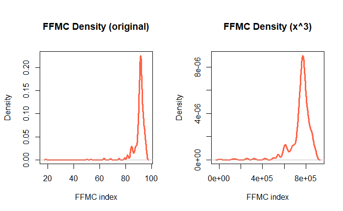

```r
par(mfrow=c(1,2),mar=c(5, 4.25, 5.5, 2))
d <- density(forestfires$FFMC)
plot(d,main="FFMC Density (original)",xlab="FFMC index", col='tomato', lwd=3)
forestfires$FFMC<- (forestfires$FFMC^3)
d <- density(forestfires$FFMC)
plot(d,main="FFMC Density (x^3)",xlab="FFMC index", col='tomato', lwd=3)
```

Since the data is skewed, we can normalize it with the below code.

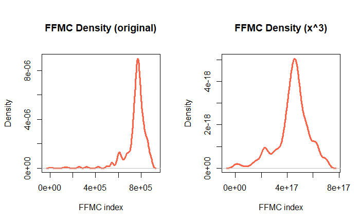

```r
par(mfrow=c(1,2),mar=c(5, 4.25, 5.5, 2))
d <- density(forestfires$FFMC)
plot(d,main="FFMC Density (original)",xlab="FFMC index", col='tomato', lwd=3)
forestfires$FFMC<- (forestfires$FFMC^3)
d <- density(forestfires$FFMC)
plot(d,main="FFMC Density (x^3)",xlab="FFMC index", col='tomato', lwd=3)
```

```r
assumptionsmodel <- lm(area ~ ., data=forestfires)
lmtest::bptest(assumptionsmodel)
```

```
    studentized Breusch-Pagan test

data:  assumptionsmodel
BP = 14.574, df = 27, p-value = 0.975
```

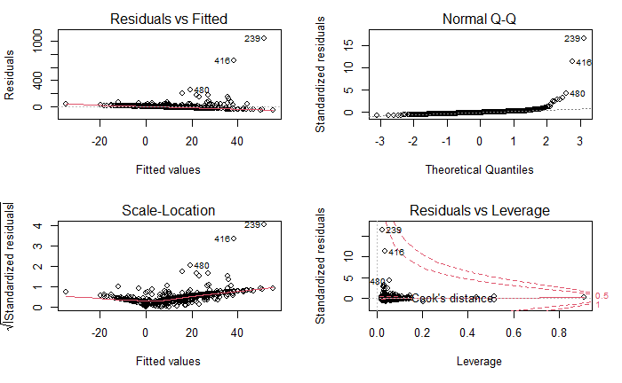

```r
par(mfrow=c(2,2))
plot(assumptionsmodel)
```

```r
model1 <- lm(area ~ ., data=forestfires)
outcome1 <- summary(model1)
(round(outcome1$coefficients[ , c(2,4)],3))
```

```
            Std. Error Pr(>|t|)
(Intercept)     36.647    0.531
X                1.499    0.134
Y                2.816    0.963
monthaug        38.312    0.223
monthdec        37.001    0.201
monthfeb        25.943    0.827
monthjan        51.396    0.734
monthjul        33.156    0.387
monthjun        30.381    0.824
monthmar        23.557    0.857
monthmay        50.905    0.804
monthnov        68.359    0.951
monthoct        45.666    0.133
monthsep        42.905    0.087
daymon          10.483    0.570
daysat          10.062    0.054
daysun           9.801    0.599
daythu          11.135    0.385
daytue          10.884    0.473
daywed          11.412    0.631
FFMC             0.000    0.951
DMC              0.087    0.022
DC               0.059    0.029
ISI              0.974    0.572
temp             1.040    0.209
RH               0.286    0.648
wind             1.781    0.267
rain             9.988    0.778
```

```r
# Find which variables are significant
sig.pred <- row.names(outcome1$coefficients)[which(outcome1$coefficients[ ,4] <= 0.05)]
rsquare <- round(summary(model1)$r.squared,3)
print(paste("The R2 value is ",rsquare))
```

```
[1] "The R2 value is  0.046"
```